# Mapping

September 10, 2025

Jo Hardin

# Agenda 9/10/25

1. `map`ping

## **purrr** for functional programming

**functionals** are functions that take function as input and return a vector / list / data frame as output.

- alternatives to loops
- a functional is better than a `for` loop is better than `while` is better than `repeat` (in terms of computing efficiency)

## Benefits

- encourages function logic to be separated from iteration logic
- can collapse into vectors/data frames easily
- direct connection to parallel processing

## Map

`map()` has (at least) two arguments, a data object and a function. It performs the function on each element of the data object and returns a list. We can also pass additional arguments into the function.

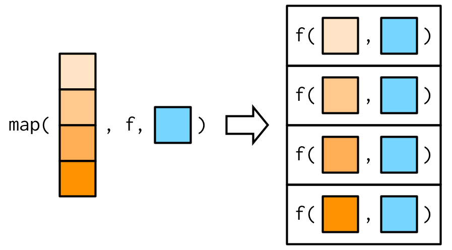

## variations of `map_` functions

The `map` functions are *named* by they **output** the produce. For example:

- `map(.x, .f)` is the main mapping function and returns a list
- `map_dbl(.x, .f)` returns a numeric (double) vector
- `map_chr(.x, .f)` returns a character vector
- `map_lgl(.x, .f)` returns a logical vector

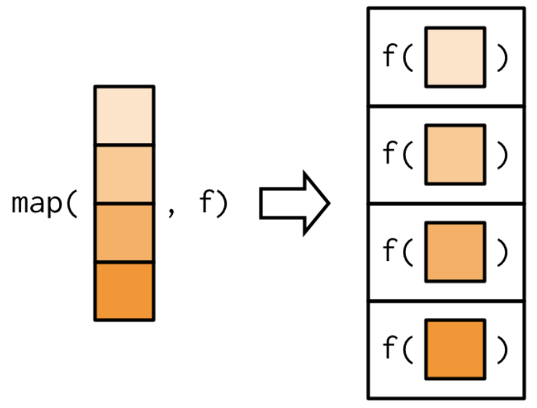

Note that the first argument is always the data object and the second object is always the function you want to iteratively apply to each element in the input object.

# `map()` in practice

## `map()` variants (output)

```r
triple <- function(x) x * 3
map(.x = c(1:3), .f = triple)
```

```
[[1]]
[1] 3

[[2]]
[1] 6

[[3]]
[1] 9
```

```r
map_dbl(.x = c(1:3), .f = triple)
```

```
[1] 3 6 9
```

```r
map_lgl(.x = c(1:3), .f = triple)
```

```
Error in `map_lgl()`:
ℹ In index: 1.
Caused by error:
! Can't coerce from a number to a logical.
```

```r
map_lgl(.x = c(1, NA, 3), .f = is.na)
```

```
[1] FALSE  TRUE FALSE
```

## `fastfood` dataset from **openintro**

```r
library(openintro)
fastfood
```

```
# A tibble: 515 × 17
   restaurant item        calories cal_fat total_fat sat_fat trans_fat
   <chr>      <chr>          <dbl>   <dbl>     <dbl>   <dbl>     <dbl>
 1 Mcdonalds  Artisan Gr…      380      60         7       2       0
 2 Mcdonalds  Single Bac…      840     410        45      17       1.5
 3 Mcdonalds  Double Bac…     1130     600        67      27       3
 4 Mcdonalds  Grilled Ba…      750     280        31      10       0.5
 5 Mcdonalds  Crispy Bac…      920     410        45      12       0.5
 6 Mcdonalds  Big Mac          540     250        28      10       1
 7 Mcdonalds  Cheeseburg…      300     100        12       5       0.5
 8 Mcdonalds  Classic Ch…      510     210        24       4       0
 9 Mcdonalds  Double Che…      430     190        21      11       1
10 Mcdonalds  Double Qua…      770     400        45      21       2.5
# ℹ 505 more rows
# ℹ 10 more variables: cholesterol <dbl>, sodium <dbl>,
#   total_carb <dbl>, fiber <dbl>, sugar <dbl>, protein <dbl>,
#   vit_a <dbl>, vit_c <dbl>, calcium <dbl>, salad <chr>
```

From [TidyTuesday Fast food entree data](https://github.com/rfordatascience/tidytuesday/tree/master/data/2018/2018-09-04) on September 4, 2018.

## Anonymous functions and shortcuts

- use `~` to set a formula (when the function is neither a single name nor defined by `function(...) { ...}`)
- use `.x` to reference the input `map(.x = ..., .f = )`

```r
map_dbl(.x = fastfood, .f = function(dog) mean(dog, na.rm = TRUE))
```

```
  restaurant         item     calories      cal_fat    total_fat      sat_fat
          NA           NA  530.9126214  238.8135922   26.5902913    8.1533981
   trans_fat  cholesterol       sodium   total_carb        fiber        sugar
   0.4650485   72.4563107 1246.7378641   45.6640777    4.1371769    7.2621359
     protein        vit_a        vit_c      calcium        salad
  27.8910506   18.8571429   20.1704918   24.8524590           NA
```

```r
map_dbl(.x = fastfood,  .f = ~mean(.x, na.rm = TRUE))
```

```
  restaurant         item     calories      cal_fat    total_fat      sat_fat
          NA           NA  530.9126214  238.8135922   26.5902913    8.1533981
   trans_fat  cholesterol       sodium   total_carb        fiber        sugar
   0.4650485   72.4563107 1246.7378641   45.6640777    4.1371769    7.2621359
     protein        vit_a        vit_c      calcium        salad
  27.8910506   18.8571429   20.1704918   24.8524590           NA
```

```r
map_dbl(.x = fastfood, .f = mean, na.rm = TRUE)
```

```
  restaurant         item     calories      cal_fat    total_fat      sat_fat
          NA           NA  530.9126214  238.8135922   26.5902913    8.1533981
   trans_fat  cholesterol       sodium   total_carb        fiber        sugar
   0.4650485   72.4563107 1246.7378641   45.6640777    4.1371769    7.2621359
     protein        vit_a        vit_c      calcium        salad
  27.8910506   18.8571429   20.1704918   24.8524590           NA
```

```r
map_dbl(.x = fastfood, .f = mean)
```

```
  restaurant         item     calories      cal_fat    total_fat      sat_fat
          NA           NA  530.9126214  238.8135922   26.5902913    8.1533981
   trans_fat  cholesterol       sodium   total_carb        fiber        sugar
   0.4650485   72.4563107 1246.7378641   45.6640777           NA    7.2621359
     protein        vit_a        vit_c      calcium        salad
          NA           NA           NA           NA           NA
```

## The same thing, many ways

Note that `.x` is the **name** of the first argument in `map()` (`.f` is the name of the second argument).

```r
# the task
map_dbl(fastfood, function(x) length(unique(x)))
```

```
 restaurant        item    calories     cal_fat   total_fat     sat_fat
          8         505         113         117          80          40
  trans_fat cholesterol      sodium  total_carb       fiber       sugar
         10          52         197         103          19          31
    protein       vit_a       vit_c     calcium       salad
         71          22          24          27           1
```

```r
map_dbl(fastfood, function(unicorn) length(unique(unicorn)))
```

```
 restaurant        item    calories     cal_fat   total_fat     sat_fat
          8         505         113         117          80          40
  trans_fat cholesterol      sodium  total_carb       fiber       sugar
         10          52         197         103          19          31
    protein       vit_a       vit_c     calcium       salad
         71          22          24          27           1
```

```r
map_dbl(fastfood, ~length(unique(.x)))
```

```
 restaurant        item    calories     cal_fat   total_fat     sat_fat
          8         505         113         117          80          40
  trans_fat cholesterol      sodium  total_carb       fiber       sugar
         10          52         197         103          19          31
    protein       vit_a       vit_c     calcium       salad
         71          22          24          27           1
```

```r
map_dbl(fastfood, ~length(unique(..1)))
```

```
 restaurant        item    calories     cal_fat   total_fat     sat_fat
          8         505         113         117          80          40
  trans_fat cholesterol      sodium  total_carb       fiber       sugar
         10          52         197         103          19          31
    protein       vit_a       vit_c     calcium       salad
         71          22          24          27           1
```

```r
map_dbl(fastfood, ~length(unique(.)))
```

```
 restaurant        item    calories     cal_fat   total_fat     sat_fat
          8         505         113         117          80          40
  trans_fat cholesterol      sodium  total_carb       fiber       sugar
         10          52         197         103          19          31
    protein       vit_a       vit_c     calcium       salad
         71          22          24          27           1
```

```r
# not the task
map_dbl(fastfood, length)
```

```
 restaurant        item    calories     cal_fat   total_fat     sat_fat
        515         515         515         515         515         515
  trans_fat cholesterol      sodium  total_carb       fiber       sugar
        515         515         515         515         515         515
    protein       vit_a       vit_c     calcium       salad
        515         515         515         515         515
```

```r
#error
map_dbl(fastfood, ~length)
```

```
Error in `map_dbl()`:
ℹ In index: 1.
ℹ With name: restaurant.
Caused by error:
! Can't coerce from a primitive function to a double.
```

```r
#error
map_dbl(fastfood, length(unique()))
```

```
Error in unique.default(): argument "x" is missing, with no default
```

```r
#error
map_dbl(fastfood, ~length(unique(x)))
```

```
Error in `map_dbl()`:
ℹ In index: 1.
ℹ With name: restaurant.
Caused by error in `.f()`:
! object 'x' not found
```

# Two+ arguments to `map()`

## `map_*()` variants (input)

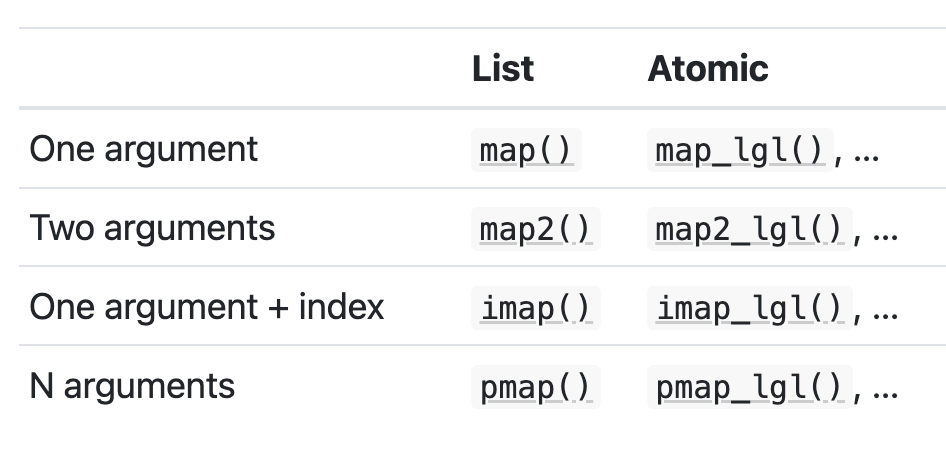

We’ve already described the difference between the columns. Now we cover the difference between the rows.

## `map2_*()`

- `map2_*()` has two arguments, `.x` and `.y`
- raise each value of `.x` to the power of 2

```r
map_dbl(
  .x = c(1:5),
  .f = function(x) x ^ 2
)
```

```
[1]  1  4  9 16 25
```

- raise each value `.x` to the power `.y`

```r
map2_dbl(
  .x = c(1:5),
  .y = c(2:6),
  .f = ~ (.x ^ .y)
)
```

```
[1]     1     8    81  1024 15625
```

## `imap()`

- `imap()` is like `map2()`except that `.y` is derived from `names(.x)` if the data frame has names.
- If not, `.y` is 1, 2, 3, … $n$ where $n$ is the number of items in `.x`. (A data frame has $n$ columns.)
- These two calls produce the same result

```r
imap_chr(.x = fastfood,
         .f = ~ paste(.y, "has a mean of", round(mean(.x), 1))) |>
head()
```

```
                    restaurant                           item
 "restaurant has a mean of NA"        "item has a mean of NA"
                      calories                        cal_fat
"calories has a mean of 530.9"  "cal_fat has a mean of 238.8"
                     total_fat                        sat_fat
"total_fat has a mean of 26.6"    "sat_fat has a mean of 8.2"
```

```r
map2_chr(.x = fastfood,
         .y = names(fastfood),
         .f = ~ paste(.y, "has a mean of", round(mean(.x), 1))) |>
head()
```

```
                    restaurant                           item
 "restaurant has a mean of NA"        "item has a mean of NA"
                      calories                        cal_fat
"calories has a mean of 530.9"  "cal_fat has a mean of 238.8"
                     total_fat                        sat_fat
"total_fat has a mean of 26.6"    "sat_fat has a mean of 8.2"
```

## `pmap()`

- you can pass a named list or dataframe as arguments to a function
- for example `runif()` has the parameters `n`, `min` and `max`

```r
params
```

```
# A tibble: 3 × 3
      n   min   max
  <dbl> <dbl> <dbl>
1     1     1    10
2     2    10   100
3     3   100  1000
```

```r
pmap(params, runif)
```

```
[[1]]
[1] 8.940795

[[2]]
[1] 46.11157 99.05758

[[3]]
[1] 719.2258 347.8249 899.3251
```

Or use the pipe into `pmap()`:

```r
params |>
  pmap(runif)
```

```
[[1]]
[1] 2.759777

[[2]]
[1] 38.46107 54.02023

[[3]]
[1] 662.2607 531.0948 304.7521
```

## An aside…

Interestingly, `runif()` will take either a scalar or a vector as its first argument. If the first argument is a vector, `runif()` will return `N` random uniforms, where `N` is the length of the vector.

```r
runif(n = 3)
```

```
[1] 0.9601774 0.5679648 0.5474585
```

```r
runif(n = c(1,3))
```

```
[1] 0.2229595 0.7244141
```

```r
runif(n = c(10000,12321412424))
```

```
[1] 0.5067011 0.6437660
```

```r
runif(n = c("rainbow", "unicorn"))
```

```
[1] 0.9116760 0.8063012
```

## `pmap()` vs `map()`

Which means that the `pmap()` code will “work” in `map()` as well:

- params
- pmap
- map

```r
params
```

```
# A tibble: 3 × 3
      n   min   max
  <dbl> <dbl> <dbl>
1     1     1    10
2     2    10   100
3     3   100  1000
```

```r
params |>
  pmap(runif)
```

```
[[1]]
[1] 7.879366

[[2]]
[1] 63.69208 26.90827

[[3]]
[1] 419.3628 920.8644 667.2142
```

```r
params |>
  map(runif)
```

```
$n
[1] 0.4550416 0.7083844 0.1961872

$min
[1] 0.5825179 0.1055289 0.0716758

$max
[1] 0.9910877 0.9648873 0.4984275
```

## `pmap()` with `expand_grid()`

- I like to use `expand_grid()` when I want all possible parameter combinations.

```r
expand_grid(n = c(1, 2, 3),
            min = c(1, 10),
            max = c(10, 100))
```

```
# A tibble: 12 × 3
       n   min   max
   <dbl> <dbl> <dbl>
 1     1     1    10
 2     1     1   100
 3     1    10    10
 4     1    10   100
 5     2     1    10
 6     2     1   100
 7     2    10    10
 8     2    10   100
 9     3     1    10
10     3     1   100
11     3    10    10
12     3    10   100
```

```r
expand_grid(n = c(1, 2, 3),
            min = c(1, 10),
            max = c(10, 100)) |>
pmap(runif)
```

```
[[1]]
[1] 5.728595

[[2]]
[1] 72.66697

[[3]]
[1] 10

[[4]]
[1] 35.10893

[[5]]
[1] 1.978005 5.660739

[[6]]
[1] 25.47767 22.37232

[[7]]
[1] 10 10

[[8]]
[1] 25.16982 43.18181

[[9]]
[1] 4.790222 7.232453 5.544764

[[10]]
[1] 36.50606 75.17531 79.35584

[[11]]
[1] 10 10 10

[[12]]
[1] 13.97496 80.37727 91.83911
```

## `map`ping to a data frame

Would be great if the results were a data frame!

- results as rows: `map() |> list_rbind()`
- results as columns: `map() |> list_cbind()`
- function
- `map()`
- with `list_rbind()`
- with `list_cbind()`

```r
col_stats <- function(n) {
  head(fastfood, n) |>
    summarise_all(mean, na.rm = TRUE) |>
    mutate_all(floor) |> # round down
    mutate(n = paste("N =", n))
}
```

```r
out1 <- map(c(10,20), col_stats)

out1
```

```
[[1]]
# A tibble: 1 × 18
  restaurant  item calories cal_fat total_fat sat_fat trans_fat
       <dbl> <dbl>    <dbl>   <dbl>     <dbl>   <dbl>     <dbl>
1         NA    NA      657     291        32      11         1
# ℹ 11 more variables: cholesterol <dbl>, sodium <dbl>,
#   total_carb <dbl>, fiber <dbl>, sugar <dbl>, protein <dbl>,
#   vit_a <dbl>, vit_c <dbl>, calcium <dbl>, salad <dbl>, n <chr>

[[2]]
# A tibble: 1 × 18
  restaurant  item calories cal_fat total_fat sat_fat trans_fat
       <dbl> <dbl>    <dbl>   <dbl>     <dbl>   <dbl>     <dbl>
1         NA    NA      582     247        27       9         0
# ℹ 11 more variables: cholesterol <dbl>, sodium <dbl>,
#   total_carb <dbl>, fiber <dbl>, sugar <dbl>, protein <dbl>,
#   vit_a <dbl>, vit_c <dbl>, calcium <dbl>, salad <dbl>, n <chr>
```

```r
out2 <- map(c(10,20), col_stats) |> list_rbind()

out2
```

```
# A tibble: 2 × 18
  restaurant  item calories cal_fat total_fat sat_fat trans_fat
       <dbl> <dbl>    <dbl>   <dbl>     <dbl>   <dbl>     <dbl>
1         NA    NA      657     291        32      11         1
2         NA    NA      582     247        27       9         0
# ℹ 11 more variables: cholesterol <dbl>, sodium <dbl>,
#   total_carb <dbl>, fiber <dbl>, sugar <dbl>, protein <dbl>,
#   vit_a <dbl>, vit_c <dbl>, calcium <dbl>, salad <dbl>, n <chr>
```

```r
out3 <- map(c(10,20), col_stats) |> list_cbind()

out3
```

```
# A tibble: 1 × 36
  restaurant...1 item...2 calories...3 cal_fat...4 total_fat...5
           <dbl>    <dbl>        <dbl>       <dbl>         <dbl>
1             NA       NA          657         291            32
# ℹ 31 more variables: sat_fat...6 <dbl>, trans_fat...7 <dbl>,
#   cholesterol...8 <dbl>, sodium...9 <dbl>, total_carb...10 <dbl>,
#   fiber...11 <dbl>, sugar...12 <dbl>, protein...13 <dbl>,
#   vit_a...14 <dbl>, vit_c...15 <dbl>, calcium...16 <dbl>,
#   salad...17 <dbl>, n...18 <chr>, restaurant...19 <dbl>,
#   item...20 <dbl>, calories...21 <dbl>, cal_fat...22 <dbl>,
#   total_fat...23 <dbl>, sat_fat...24 <dbl>, trans_fat...25 <dbl>, …
```